# final_project_md

sheom

2021 6 17

**2019-14505 엄세희** **수시과제2 : 연령에 따른 감성분석**

**- 가설: 연령에 따라서 감성점수의 분포가 다를 것이다.**

```r
library(tidyverse)
library(jsonlite)
files = list.files(pattern = "^S.+json$", full.names = T)
```

가설을 검정하기 위해서는 말뭉치 데이터, 그리고 화자 데이터가 필요합니다. 감성분석을 하기 위해 하나의 행에 단어 하나가 오는 데이터프레임을 형성합니다. 그 전에, 먼저 말뭉치 데이터와 화자 데이터를 가져옵니다.

말뭉치 데이터 (감성분석 대상) 가져오기

```r
get_utterance <- function(x) {
  json_utterance = fromJSON(x) %>% .$document %>% .$utterance
  bind_rows(json_utterance)
}
df_spoken = map(files, get_utterance) %>% bind_rows()
```

화자 데이터 가져오기

```r
get_speaker <- function(x) {
  json = fromJSON(x) %>% .$document %>% .$metadata %>% .$speaker
}
df_speaker = map(files, get_speaker) %>% bind_rows()
```

말뭉치를 문장 단위로 분리한 데이터프레임 만들기

```r
df_spoken_sentence = df_spoken %>%
  mutate(end = str_detect(original_form, pattern ="(\\.|\\?|\\!)" )) %>%
  mutate(sentence_no = cumsum(end) %>% lag() + 1) %>%
  mutate(sentence_no = ifelse(is.na(sentence_no), 1, sentence_no)) %>%
  mutate(doc_id = str_extract(id, "SDRW[0-9]+")) %>%
  mutate(seq_id = str_extract(id, "[0-9]+$")) %>%
  select(doc_id, speaker_id, sentence_no, seq_id, original_form)

df_collapsed_sentence = df_spoken_sentence %>% group_by(doc_id, speaker_id, sentence_no) %>%
  summarise(sentence = str_c(original_form, collapse = " "))
```

감성분석을 위해 sentence number가 붙은 단어들로 나누기

```r
df_spoken_word = df_collapsed_sentence %>%
  mutate(word = str_split(sentence, " ")) %>%
  unnest(word) %>%
  select(doc_id, speaker_id, sentence_no, word)
```

감성사전: 감성사전은 단어 단위로 감성 점수 부여한 json파일입니다. 해당 json파일에 존재하는 단어들을 끌고와서 단어단위로 쪼갠 데이터프레임에 적용해야 합니다.

```r
sentiment = fromJSON("https://raw.githubusercontent.com/park1200656/KnuSentiLex/master/data/SentiWord_info.json")
df_sentiment = sentiment %>% filter(nchar(word_root)> 1) %>% select(word_root, polarity) %>%
  unique() %>%  group_by(word_root) %>% summarise(polarity = max(polarity)) %>% mutate(polarity = as.numeric(polarity))
```

단어로 분리된 데이터프레임 감성분석 화자별 분석: 감성사전의 polarity를 추가합니다.

```r
sentiment_by_speaker = df_spoken_word %>%
  left_join(df_sentiment, by = c("word" ="word_root")) %>%
  arrange(polarity) %>%
  group_by(doc_id, speaker_id) %>% summarise(sum = sum(polarity, na.rm = T)) %>% select(doc_id, id=speaker_id, sum)
df_speaker <- df_speaker %>% left_join(sentiment_by_speaker, by = "id")
```

**- 텍스트 마이닝 시각화 1** 화자별 감성 점수를 나이대별로 구분하여 시각화합니다.

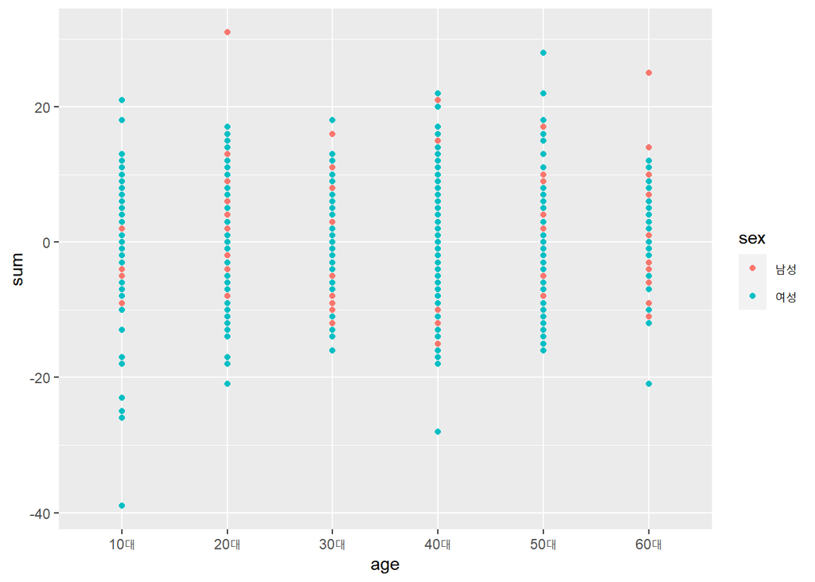

```r
df_speaker %>% ggplot(aes(x=age, y = sum, color=sex)) + geom_point()
```

**- 통계적 가설 검정:** 나이대별 감성 점수를 알아볼 것이기 때문에, 그룹 간 비교를 해야 합니다. 그룹 간 비교는 분산분석(anova)을 이용합니다. 분산분석이란, 그룹 내 분산, 그룹 간 분산을 이용하여 구한 F분포(f-value)를 이용한 가설검정 방법입니다. f분포는 그룹 간 분산평균을 그룹 내 분산평균으로 나눈 값입니다. 나이 그룹 간 감성 점수 분포가 뚜렷하게 다르려면, 그룹 내 분산평균은 작고, 그룹 간 분산평균은 커야 합니다. 따라서 f값이 클수록 나이대가 감성점수에 미치는 영향이 크다고 볼 수 있습니다.

감성 점수의 평균, 분산을 계산합니다. 그룹별(나이대별) 분산, 나이대 내의 분산을 모두 추가합니다.

```r
df_sent_mean = df_speaker %>% select(age, sum) %>% group_by(age) %>% summarise(n= n(), Mean = mean(sum))
df_sent_variance = df_speaker %>%  select(id, age, sum) %>% group_by(age) %>%
  mutate(mean_age = mean(sum),
         sd_age = sum - mean(sum)) %>%
  ungroup() %>%
  mutate(mean = mean(sum), sd = sum - mean(sum)) %>%
  mutate(variance_within_age = sd_age^2) %>%
  mutate(variance_among_age = (mean-mean_age)^2)
```

평균, 분산(그룹 내, 그룹 간 분산)을 포함한 화자 별 감성점수 테이블

```r
df_sent_variance %>% rmarkdown::paged_table()
```

| id | age | sum | mean_age | sd_age | mean | sd | variance_within_age | variance_among_age |
| --- | --- | --- | --- | --- | --- | --- | --- | --- |
| SD2000001 | 20대 | 2 | 0.8458130 | 1.1541870 | 0.4325076 | 1.5674924 | 1.332148e+00 | 0.170821389 |
| SD2000002 | 20대 | 0 | 0.8458130 | -0.8458130 | 0.4325076 | -0.4325076 | 7.153997e-01 | 0.170821389 |
| SD2000003 | 30대 | 5 | 0.4900315 | 4.5099685 | 0.4325076 | 4.5674924 | 2.033982e+01 | 0.003308999 |
| SD2000004 | 20대 | 1 | 0.8458130 | 0.1541870 | 0.4325076 | 0.5674924 | 2.377362e-02 | 0.170821389 |
| SD2000005 | 10대 | 0 | 0.7863683 | -0.7863683 | 0.4325076 | -0.4325076 | 6.183750e-01 | 0.125217379 |
| SD2000006 | 30대 | 1 | 0.4900315 | 0.5099685 | 0.4325076 | 0.5674924 | 2.600679e-01 | 0.003308999 |
| SD2000006 | 30대 | -5 | 0.4900315 | -5.4900315 | 0.4325076 | -5.4325076 | 3.014045e+01 | 0.003308999 |
| SD2000007 | 10대 | 4 | 0.7863683 | 3.2136317 | 0.4325076 | 3.5674924 | 1.032743e+01 | 0.125217379 |
| SD2000006 | 30대 | 1 | 0.4900315 | 0.5099685 | 0.4325076 | 0.5674924 | 2.600679e-01 | 0.003308999 |
| SD2000006 | 30대 | -5 | 0.4900315 | -5.4900315 | 0.4325076 | -5.4325076 | 3.014045e+01 | 0.003308999 |

[output cut: 7902 more lines]

AOV함수를 이용한 anova분석 f값이 10.4로 나타납니다.

```r
result = aov(sum ~ age, data = df_speaker)
broom::tidy(result)
```

```
## # A tibble: 2 x 6
##   term         df   sumsq meansq statistic   p.value
##   <chr>     <dbl>   <dbl>  <dbl>     <dbl>     <dbl>
## 1 age           5   1147.  229.       10.4  5.95e-10
## 2 Residuals  7906 174497.   22.1      NA   NA
```

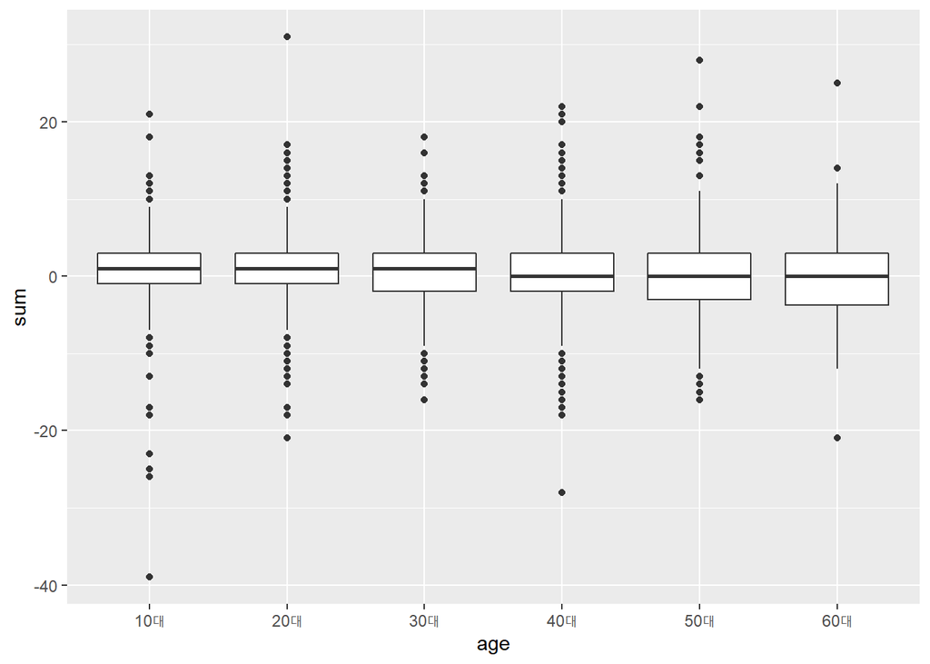

```r
df_sent_variance %>%
  ggplot(aes(x=age, y = sum)) + geom_boxplot()
```

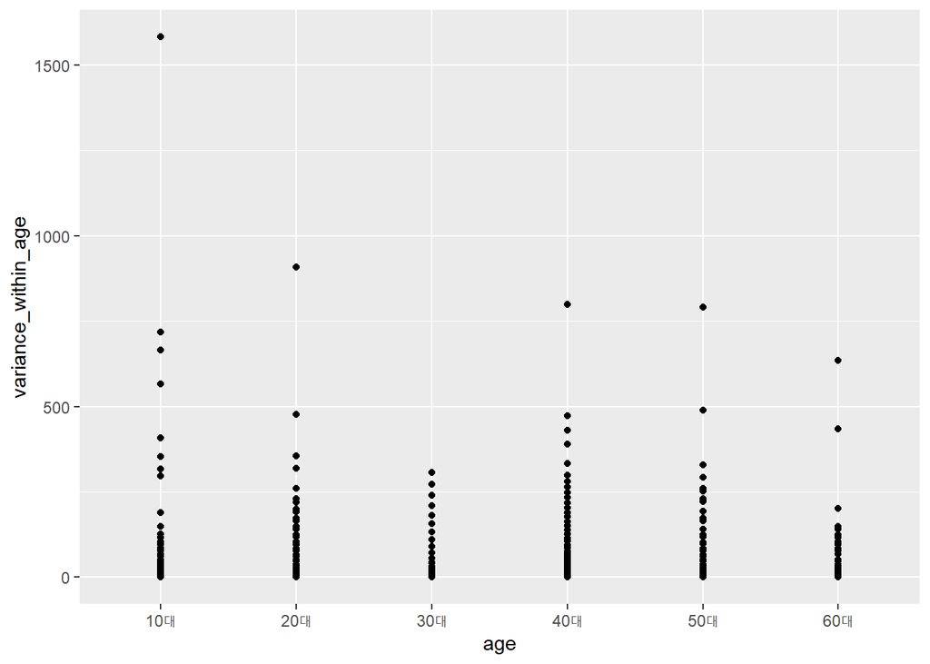

```r
df_sent_variance %>%
  ggplot(aes(x = age, y = variance_within_age)) + geom_point()
```

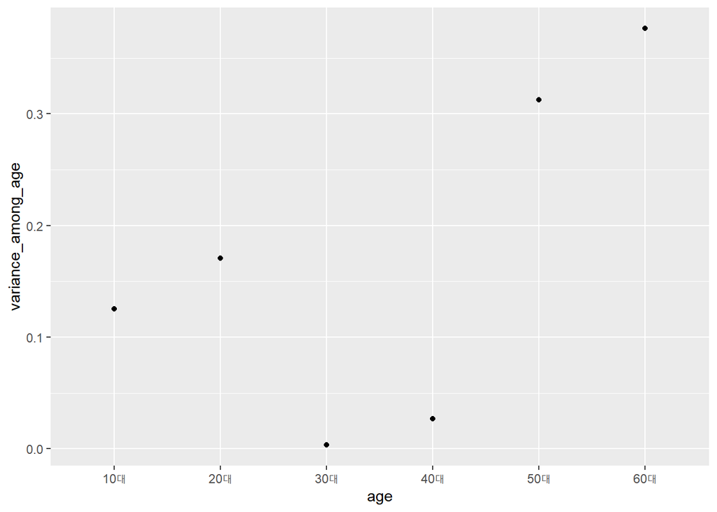

```r
df_sent_variance %>%
  ggplot(aes(x = age, y = variance_among_age)) + geom_point()
```